# ClimateChangeProject

**Climate Change and The Problems It Could Pose In The Future**

By Francisco Soltero

```python
import pandas as pd
import numpy as np
import matplotlib.pyplot as plt
import string
import re

pd.options.mode.copy_on_write = True
np.random.seed(1)
```

```python
from google.colab import drive
drive.mount('/content/drive')
%cd /content/drive/MyDrive/Colab\ Notebooks/FinalizedData
%ls
```

```
/content/drive/MyDrive/Colab Notebooks/FinalizedData
GlobalLandTemperaturesByCity.csv       GlobalLandTemperaturesByState.csv
GlobalLandTemperaturesByCountry.csv    GlobalTemperatures.csv
GlobalLandTemperaturesByMajorCity.csv
```

```python
%%shell
cd ..
ls
jupyter nbconvert ClimateChangeProject.ipynb --to html
```

[output not shown]

**Project Goals**

**Website**: https://frankiesoltero.github.io/DataScienceProject/

**Data Frames**: Below in our code cell we see our 5 defined data frames.

global_temperatures: Contains the global temperatures from 1750 - 2015, we will use this for a future model to predict the temperature for years after 2015.

global_land_temps_bycity: This contains the land temperatures by city and the average temperature uncertainty for every city in the world.

global_land_temps_bycountry: This is the same idea as the city data frame, except it contains every country in the world.

global_land_temps_by_major_city: The same idea as per city except uses all the major cities in the world.

global_land_temps_by_state: Ideal for comparing the situations in regard to average temperature in the states.

```python
import glob
import requests
from bs4 import BeautifulSoup

global_temperatures = pd.read_csv("GlobalTemperatures.csv")
global_land_temps_bycity = pd.read_csv("GlobalLandTemperaturesByCity.csv")
global_land_temps_bycountry = pd.read_csv("GlobalLandTemperaturesByCountry.csv")
global_land_temps_by_major_city = pd.read_csv("GlobalLandTemperaturesByMajorCity.csv")
global_land_temps_by_state = pd.read_csv("GlobalLandTemperaturesByState.csv")
```

**Data Types**:

Global Land Temperaure by State:

- dt DateTime Object
- AverageTemperature float64
- AverageTemperatureUncertainty float64
- State object
- Country object
- dtype: object

GLT by Major City:

- dt DateTime Object
- AverageTemperature float64
- AverageTemperatureUncertainty float64
- City object
- Country object
- Latitude object
- Longitude object
- dtype: object

GLT by Country:

- dt DateTime Object
- AverageTemperature float64
- AverageTemperatureUncertainty float64
- Country object
- dtype: object

GLT by City:

- dt DateTime Object
- AverageTemperature float64
- AverageTemperatureUncertainty float64
- City object
- Country object
- Latitude object
- Longitude object
- dtype: object

Global Temperatures:

- dt DateTime Object
- LandAverageTemperature float64
- LandAverageTemperatureUncertainty float64
- LandMaxTemperature float64
- LandMaxTemperatureUncertainty float64
- LandMinTemperature float64
- LandMinTemperatureUncertainty float64
- LandAndOceanAverageTemperature float64
- LandAndOceanAverageTemperatureUncertainty float64
- dtype: object

```python
data_frames = [global_land_temps_by_state, global_land_temps_by_major_city, global_land_temps_bycountry, global_land_temps_bycity, global_temperatures]
for df in data_frames:
  display(df)
```

|  | dt | AverageTemperature | AverageTemperatureUncertainty | State | Country |
| --- | --- | --- | --- | --- | --- |
| 0 | 1855-05-01 | 25.544 | 1.171 | Acre | Brazil |
| 1 | 1855-06-01 | 24.228 | 1.103 | Acre | Brazil |
| 2 | 1855-07-01 | 24.371 | 1.044 | Acre | Brazil |
| 3 | 1855-08-01 | 25.427 | 1.073 | Acre | Brazil |
| 4 | 1855-09-01 | 25.675 | 1.014 | Acre | Brazil |
| ... | ... | ... | ... | ... | ... |
| 645670 | 2013-05-01 | 21.634 | 0.578 | Zhejiang | China |
| 645671 | 2013-06-01 | 24.679 | 0.596 | Zhejiang | China |
| 645672 | 2013-07-01 | 29.272 | 1.340 | Zhejiang | China |
| 645673 | 2013-08-01 | 29.202 | 0.869 | Zhejiang | China |
| 645674 | 2013-09-01 | NaN | NaN | Zhejiang | China |

645675 rows × 5 columns

|  | dt | AverageTemperature | AverageTemperatureUncertainty | City | Country | Latitude | Longitude |
| --- | --- | --- | --- | --- | --- | --- | --- |
| 0 | 1849-01-01 | 26.704 | 1.435 | Abidjan | Côte D'Ivoire | 5.63N | 3.23W |
| 1 | 1849-02-01 | 27.434 | 1.362 | Abidjan | Côte D'Ivoire | 5.63N | 3.23W |
| 2 | 1849-03-01 | 28.101 | 1.612 | Abidjan | Côte D'Ivoire | 5.63N | 3.23W |
| 3 | 1849-04-01 | 26.140 | 1.387 | Abidjan | Côte D'Ivoire | 5.63N | 3.23W |
| 4 | 1849-05-01 | 25.427 | 1.200 | Abidjan | Côte D'Ivoire | 5.63N | 3.23W |
| ... | ... | ... | ... | ... | ... | ... | ... |
| 239172 | 2013-05-01 | 18.979 | 0.807 | Xian | China | 34.56N | 108.97E |
| 239173 | 2013-06-01 | 23.522 | 0.647 | Xian | China | 34.56N | 108.97E |
| 239174 | 2013-07-01 | 25.251 | 1.042 | Xian | China | 34.56N | 108.97E |
| 239175 | 2013-08-01 | 24.528 | 0.840 | Xian | China | 34.56N | 108.97E |
| 239176 | 2013-09-01 | NaN | NaN | Xian | China | 34.56N | 108.97E |

239177 rows × 7 columns

|  | dt | AverageTemperature | AverageTemperatureUncertainty | Country |
| --- | --- | --- | --- | --- |
| 0 | 1743-11-01 | 4.384 | 2.294 | Åland |
| 1 | 1743-12-01 | NaN | NaN | Åland |
| 2 | 1744-01-01 | NaN | NaN | Åland |
| 3 | 1744-02-01 | NaN | NaN | Åland |
| 4 | 1744-03-01 | NaN | NaN | Åland |
| ... | ... | ... | ... | ... |
| 577457 | 2013-05-01 | 19.059 | 1.022 | Zimbabwe |
| 577458 | 2013-06-01 | 17.613 | 0.473 | Zimbabwe |
| 577459 | 2013-07-01 | 17.000 | 0.453 | Zimbabwe |
| 577460 | 2013-08-01 | 19.759 | 0.717 | Zimbabwe |
| 577461 | 2013-09-01 | NaN | NaN | Zimbabwe |

577462 rows × 4 columns

|  | dt | AverageTemperature | AverageTemperatureUncertainty | City | Country | Latitude | Longitude |
| --- | --- | --- | --- | --- | --- | --- | --- |
| 0 | 1743-11-01 | 6.068 | 1.737 | Århus | Denmark | 57.05N | 10.33E |
| 1 | 1743-12-01 | NaN | NaN | Århus | Denmark | 57.05N | 10.33E |
| 2 | 1744-01-01 | NaN | NaN | Århus | Denmark | 57.05N | 10.33E |
| 3 | 1744-02-01 | NaN | NaN | Århus | Denmark | 57.05N | 10.33E |
| 4 | 1744-03-01 | NaN | NaN | Århus | Denmark | 57.05N | 10.33E |
| ... | ... | ... | ... | ... | ... | ... | ... |
| 8599207 | 2013-05-01 | 11.464 | 0.236 | Zwolle | Netherlands | 52.24N | 5.26E |
| 8599208 | 2013-06-01 | 15.043 | 0.261 | Zwolle | Netherlands | 52.24N | 5.26E |
| 8599209 | 2013-07-01 | 18.775 | 0.193 | Zwolle | Netherlands | 52.24N | 5.26E |
| 8599210 | 2013-08-01 | 18.025 | 0.298 | Zwolle | Netherlands | 52.24N | 5.26E |
| 8599211 | 2013-09-01 | NaN | NaN | Zwolle | Netherlands | 52.24N | 5.26E |

8599212 rows × 7 columns

|  | dt | LandAverageTemperature | LandAverageTemperatureUncertainty | LandMaxTemperature | LandMaxTemperatureUncertainty | LandMinTemperature | LandMinTemperatureUncertainty | LandAndOceanAverageTemperature | LandAndOceanAverageTemperatureUncertainty |
| --- | --- | --- | --- | --- | --- | --- | --- | --- | --- |
| 0 | 1750-01-01 | 3.034 | 3.574 | NaN | NaN | NaN | NaN | NaN | NaN |
| 1 | 1750-02-01 | 3.083 | 3.702 | NaN | NaN | NaN | NaN | NaN | NaN |
| 2 | 1750-03-01 | 5.626 | 3.076 | NaN | NaN | NaN | NaN | NaN | NaN |
| 3 | 1750-04-01 | 8.490 | 2.451 | NaN | NaN | NaN | NaN | NaN | NaN |
| 4 | 1750-05-01 | 11.573 | 2.072 | NaN | NaN | NaN | NaN | NaN | NaN |
| ... | ... | ... | ... | ... | ... | ... | ... | ... | ... |
| 3187 | 2015-08-01 | 14.755 | 0.072 | 20.699 | 0.110 | 9.005 | 0.170 | 17.589 | 0.057 |
| 3188 | 2015-09-01 | 12.999 | 0.079 | 18.845 | 0.088 | 7.199 | 0.229 | 17.049 | 0.058 |
| 3189 | 2015-10-01 | 10.801 | 0.102 | 16.450 | 0.059 | 5.232 | 0.115 | 16.290 | 0.062 |
| 3190 | 2015-11-01 | 7.433 | 0.119 | 12.892 | 0.093 | 2.157 | 0.106 | 15.252 | 0.063 |
| 3191 | 2015-12-01 | 5.518 | 0.100 | 10.725 | 0.154 | 0.287 | 0.099 | 14.774 | 0.062 |

3192 rows × 9 columns

**Global Temperatures On the Rise**: From the graph below we can see a clear increase in the global temperatures from 1750 until now. This is a clear indicator that climate change is thoroughly in action. We can also see how the Uncertainty lowers as the years increase due to the advancements made in technology. The uncertainty of the data decreases as we found more ways to measure the temperature.

| dt | LandAverageTemperature | LandAverageTemperatureUncertainty | LandMaxTemperature | LandMaxTemperatureUncertainty | LandMinTemperature | LandMinTemperatureUncertainty | LandAndOceanAverageTemperature | LandAndOceanAverageTemperatureUncertainty |
| --- | --- | --- | --- | --- | --- | --- | --- | --- |
| 1750 | 8.719364 | 2.637818 | NaN | NaN | NaN | NaN | NaN | NaN |
| 1751 | 7.976143 | 2.781143 | NaN | NaN | NaN | NaN | NaN | NaN |
| 1752 | 5.779833 | 2.977000 | NaN | NaN | NaN | NaN | NaN | NaN |
| 1753 | 8.388083 | 3.176000 | NaN | NaN | NaN | NaN | NaN | NaN |
| 1754 | 8.469333 | 3.494250 | NaN | NaN | NaN | NaN | NaN | NaN |
| ... | ... | ... | ... | ... | ... | ... | ... | ... |
| 2011 | 9.516000 | 0.082000 | 15.284833 | 0.114333 | 3.827667 | 0.136583 | 15.769500 | 0.059000 |
| 2012 | 9.507333 | 0.083417 | 15.332833 | 0.107333 | 3.756167 | 0.145333 | 15.802333 | 0.061500 |
| 2013 | 9.606500 | 0.097667 | 15.373833 | 0.115500 | 3.911333 | 0.149833 | 15.854417 | 0.064667 |
| 2014 | 9.570667 | 0.090167 | 15.313583 | 0.111667 | 3.877750 | 0.139000 | 15.913000 | 0.063167 |
| 2015 | 9.831000 | 0.092167 | 15.572667 | 0.106500 | 4.148833 | 0.141750 | 16.058583 | 0.060833 |

266 rows × 8 columns

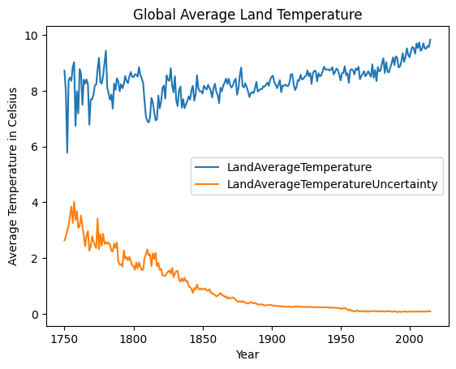

```python
global_temperatures['dt'] = pd.to_datetime(global_temperatures['dt'])
temp_df = global_temperatures.set_index('dt')
average_global_temps_yearly = temp_df.groupby([temp_df.index.year]).mean()
average_global_temps_yearly[['LandAverageTemperature', 'LandAverageTemperatureUncertainty']].plot.line(xlabel='Year', ylabel='Average Temperature in Celsius', title='Global Average Land Temperature')
display(average_global_temps_yearly)
```

As we can see the difference in temperature from 1750 to 2015 may not look like much but a 1 degree difference around the world means that for many different places there could be a huge difference. I will now investigate this in the next section, where I will see what the differences are for each country.

```python
difference_from_1750_2015 = average_global_temps_yearly.iloc[-1:]['LandAverageTemperature'] - average_global_temps_yearly.iloc[0]['LandAverageTemperature']
print(f"The Difference from 1750 to 2015 is {difference_from_1750_2015.iloc[0]} Degrees Celsius in Land Temperature")
```

```
The Difference from 1750 to 2015 is 1.1116363636363626 Degrees Celsius in Land Temperature
```

**Country Temperature Averages**: In this section I can now investigate the increases for specific countries.

```python
global_land_temps_bycountry['dt'] = pd.to_datetime(global_land_temps_bycountry['dt'])
temps_df = global_land_temps_bycountry
# Here we group by country and year and then use the average temperature and take the mean to get the year totals, and then we rename our indexes for clarity
temps_df = temps_df.groupby([temps_df['Country'], temps_df['dt'].dt.year]).agg({'AverageTemperature':'mean'}).rename_axis(index=['Country', 'Year']).reset_index()
# We then create a pivot table to compare the countries
pivot = temps_df.pivot(index='Country', columns='Year', values='AverageTemperature')
# We take the 100 year difference
pivot['Greatest Total Temp Increase'] = pivot[2013] - pivot[1910]
pivot_sorted = pivot.sort_values(by='Greatest Total Temp Increase', ascending=False)
# Then we drop any nans
pivot_sorted = pivot_sorted.dropna(subset=['Greatest Total Temp Increase'])
# Then finally we display the 5 highest and the 5 lowest
display(pivot_sorted['Greatest Total Temp Increase'].head(5))
display(pivot_sorted['Greatest Total Temp Increase'].tail(5))
```

| Country | Greatest Total Temp Increase |
| --- | --- |
| Greenland | 4.661500 |
| Mongolia | 4.639083 |
| Denmark | 4.566333 |
| Uzbekistan | 4.125917 |
| Turkmenistan | 4.047333 |

**dtype:** float64

| Country | Greatest Total Temp Increase |
| --- | --- |
| Guernsey | 0.005708 |
| Jersey | 0.005708 |
| Åland | -0.016917 |
| Denmark (Europe) | -0.065042 |
| Paraguay | -0.147333 |

**dtype:** float64

**Result**: As we can see the country with the greatest temperature increase within the past 100 years is Greenland with a 4.66 degree increase. This is insane because just imagine how hot it will be in Greenland in 100 more years. The drastic weather changes will damage a lot of the local eco systems for the native animals in those top 5 countries. We can also see the lowest 5 countries being the ones who have to worry the lease about climate change. It is pretty evident that these countries are doing something right to avoid having a drastic change in their weather.

**Seasonal Data Frames**: In this section I go through and apply a seasonal category to each year. This will allow us to now go through and make scatter plots for each season, and then we can truly see how much the weather is changing through these seasons. Once this is done then we can move on to making our linear regression model to precidct what the weather will look like in the future.

```python
# We use this dictionary to map the seasons together
seasons = {
    (1,2,12): "W",
    (3,4,5): "SP",
    (6,7,8): "S",
    (9,10,11): "F"
}
# We get the month to use for the seasons
global_temperatures['Month'] = global_temperatures['dt'].dt.month
def apply_seasons(ser):
  for k in seasons.keys():
    if ser in k:
      return seasons[k]
global_temperatures['Season'] = global_temperatures['Month'].apply(apply_seasons)
working_df = global_temperatures.set_index('dt')
# We then group by our year and season
df = working_df.groupby([working_df.index.year, 'Season']).mean()
df = df.reset_index()
df = df.drop(['Month'], axis=1)
# Seperate our Data frames into their own season based data frame
fall_df = df[df['Season'] == 'F']
winter_df = df[df['Season'] == 'W']
spring_df = df[df['Season'] == 'SP']
summer_df = df[df['Season'] == "S"]
display(fall_df)
display(winter_df)
display(spring_df)
display(summer_df)
```

|  | dt | Season | LandAverageTemperature | LandAverageTemperatureUncertainty | LandMaxTemperature | LandMaxTemperatureUncertainty | LandMinTemperature | LandMinTemperatureUncertainty | LandAndOceanAverageTemperature | LandAndOceanAverageTemperatureUncertainty |
| --- | --- | --- | --- | --- | --- | --- | --- | --- | --- | --- |
| 0 | 1750 | F | 8.890000 | 2.652500 | NaN | NaN | NaN | NaN | NaN | NaN |
| 4 | 1751 | F | 10.673000 | 2.656000 | NaN | NaN | NaN | NaN | NaN | NaN |
| 8 | 1752 | F | 7.587000 | 2.750500 | NaN | NaN | NaN | NaN | NaN | NaN |
| 12 | 1753 | F | 9.212333 | 2.643333 | NaN | NaN | NaN | NaN | NaN | NaN |
| 16 | 1754 | F | 8.957333 | 2.631667 | NaN | NaN | NaN | NaN | NaN | NaN |
| ... | ... | ... | ... | ... | ... | ... | ... | ... | ... | ... |
| 1044 | 2011 | F | 10.026000 | 0.092333 | 15.786667 | 0.104667 | 4.426667 | 0.139333 | 15.811333 | 0.058667 |
| 1048 | 2012 | F | 10.208000 | 0.094333 | 15.988667 | 0.114000 | 4.579000 | 0.149667 | 15.967333 | 0.062333 |
| 1052 | 2013 | F | 10.278000 | 0.086667 | 15.968667 | 0.096667 | 4.720333 | 0.148333 | 15.968667 | 0.062667 |
| 1056 | 2014 | F | 10.044667 | 0.094333 | 15.738333 | 0.113667 | 4.467000 | 0.132000 | 15.967667 | 0.060667 |
| 1060 | 2015 | F | 10.411000 | 0.100000 | 16.062333 | 0.080000 | 4.862667 | 0.150000 | 16.197000 | 0.061000 |

266 rows × 10 columns

|  | dt | Season | LandAverageTemperature | LandAverageTemperatureUncertainty | LandMaxTemperature | LandMaxTemperatureUncertainty | LandMinTemperature | LandMinTemperatureUncertainty | LandAndOceanAverageTemperature | LandAndOceanAverageTemperatureUncertainty |
| --- | --- | --- | --- | --- | --- | --- | --- | --- | --- | --- |
| 3 | 1750 | W | 2.963000 | 3.415333 | NaN | NaN | NaN | NaN | NaN | NaN |
| 7 | 1751 | W | 1.729000 | 3.648000 | NaN | NaN | NaN | NaN | NaN | NaN |
| 11 | 1752 | W | 2.717000 | 3.385500 | NaN | NaN | NaN | NaN | NaN | NaN |
| 15 | 1753 | W | 1.104333 | 4.664333 | NaN | NaN | NaN | NaN | NaN | NaN |
| 19 | 1754 | W | 1.637333 | 5.270333 | NaN | NaN | NaN | NaN | NaN | NaN |
| ... | ... | ... | ... | ... | ... | ... | ... | ... | ... | ... |
| 1047 | 2011 | W | 3.893333 | 0.085000 | 9.418333 | 0.118667 | -1.527000 | 0.123333 | 14.106333 | 0.060333 |
| 1051 | 2012 | W | 3.629000 | 0.092333 | 9.189333 | 0.122667 | -1.820667 | 0.119333 | 14.053667 | 0.062333 |
| 1055 | 2013 | W | 4.210333 | 0.091667 | 9.762667 | 0.113333 | -1.248667 | 0.113667 | 14.271667 | 0.064667 |
| 1059 | 2014 | W | 4.027333 | 0.077667 | 9.554333 | 0.119667 | -1.388667 | 0.103000 | 14.234333 | 0.063667 |
| 1063 | 2015 | W | 4.687667 | 0.117000 | 10.218000 | 0.112000 | -0.789667 | 0.103000 | 14.531000 | 0.065000 |

266 rows × 10 columns

|  | dt | Season | LandAverageTemperature | LandAverageTemperatureUncertainty | LandMaxTemperature | LandMaxTemperatureUncertainty | LandMinTemperature | LandMinTemperatureUncertainty | LandAndOceanAverageTemperature | LandAndOceanAverageTemperatureUncertainty |
| --- | --- | --- | --- | --- | --- | --- | --- | --- | --- | --- |
| 2 | 1750 | SP | 8.563000 | 2.533000 | NaN | NaN | NaN | NaN | NaN | NaN |
| 6 | 1751 | SP | 6.735000 | 2.709500 | NaN | NaN | NaN | NaN | NaN | NaN |
| 10 | 1752 | SP | 7.035500 | 2.795000 | NaN | NaN | NaN | NaN | NaN | NaN |
| 14 | 1753 | SP | 8.627333 | 3.072333 | NaN | NaN | NaN | NaN | NaN | NaN |
| 18 | 1754 | SP | 9.074333 | 3.522000 | NaN | NaN | NaN | NaN | NaN | NaN |
| ... | ... | ... | ... | ... | ... | ... | ... | ... | ... | ... |
| 1046 | 2011 | SP | 9.190000 | 0.055333 | 15.110000 | 0.118333 | 3.287000 | 0.156000 | 15.745000 | 0.057333 |
| 1050 | 2012 | SP | 9.429667 | 0.072667 | 15.438333 | 0.106333 | 3.408333 | 0.155333 | 15.814333 | 0.061333 |
| 1054 | 2013 | SP | 9.166667 | 0.097333 | 15.173000 | 0.126000 | 3.164000 | 0.171667 | 15.770000 | 0.065333 |
| 1058 | 2014 | SP | 9.516333 | 0.092333 | 15.419333 | 0.118667 | 3.555333 | 0.166000 | 15.977333 | 0.065333 |
| 1062 | 2015 | SP | 9.455000 | 0.076333 | 15.354667 | 0.116667 | 3.536333 | 0.126333 | 15.976333 | 0.060000 |

266 rows × 10 columns

|  | dt | Season | LandAverageTemperature | LandAverageTemperatureUncertainty | LandMaxTemperature | LandMaxTemperatureUncertainty | LandMinTemperature | LandMinTemperatureUncertainty | LandAndOceanAverageTemperature | LandAndOceanAverageTemperatureUncertainty |
| --- | --- | --- | --- | --- | --- | --- | --- | --- | --- | --- |
| 1 | 1750 | S | 14.518333 | 1.955333 | NaN | NaN | NaN | NaN | NaN | NaN |
| 5 | 1751 | S | 14.116000 | 2.048500 | NaN | NaN | NaN | NaN | NaN | NaN |
| 9 | 1752 | S | NaN | NaN | NaN | NaN | NaN | NaN | NaN | NaN |
| 13 | 1753 | S | 14.608333 | 2.324000 | NaN | NaN | NaN | NaN | NaN | NaN |
| 17 | 1754 | S | 14.208333 | 2.553000 | NaN | NaN | NaN | NaN | NaN | NaN |
| ... | ... | ... | ... | ... | ... | ... | ... | ... | ... | ... |
| 1045 | 2011 | S | 14.954667 | 0.095333 | 20.824333 | 0.115667 | 9.124000 | 0.127667 | 17.415333 | 0.059667 |
| 1049 | 2012 | S | 14.762667 | 0.074333 | 20.715000 | 0.086333 | 8.858000 | 0.157000 | 17.374000 | 0.060000 |
| 1053 | 2013 | S | 14.771000 | 0.115000 | 20.591000 | 0.126000 | 9.009667 | 0.165667 | 17.407333 | 0.066000 |
| 1057 | 2014 | S | 14.694333 | 0.096333 | 20.542333 | 0.094667 | 8.877333 | 0.155000 | 17.472667 | 0.063000 |
| 1061 | 2015 | S | 14.770333 | 0.075333 | 20.655667 | 0.117333 | 8.986000 | 0.187667 | 17.530000 | 0.057333 |

266 rows × 10 columns

Before we go into the next section that outlines the temperature changes in each season, https://greenly.earth/en-us/blog/ecology-news/what-would-be-the-impact-of-a-3degc-rise-in-global-temperature, this article does a great job at explaining how drastic these changes in temperature could be for our environment.

**Plots for Each Season**: As we can see from our graphs below there is strong evidence that global warming is increasing our temperature. In fall and winter there is a positive line that the temperature is increasing. This further helps prove my hypothesis that the world is getting warmer which is really bad news for our climate!

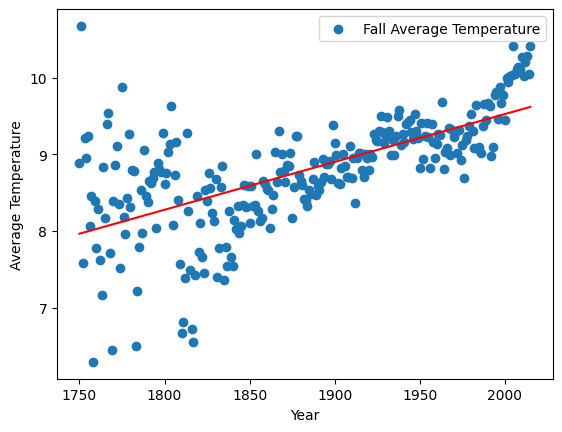

```python
# We first set our x and y to be the date and Average Land temp, then we use np.polyfit to get our slope and intercept
# Then we create our scatter and plot the linear regression of the scatter plot
x = fall_df['dt']
y = fall_df['LandAverageTemperature']
slope, intercept = np.polyfit(x,y,1)
plt.scatter(x, y, label='Fall Average Temperature')
plt.plot(x, x*slope + intercept, 'r')
plt.xlabel('Year')
plt.ylabel('Average Temperature')
plt.legend()
plt.show()
```

```
Year 1750: Predicted Temp = 7.96
Year 1751: Predicted Temp = 7.97
Year 1752: Predicted Temp = 7.98
Year 1753: Predicted Temp = 7.98
Year 1754: Predicted Temp = 7.99
Year 1755: Predicted Temp = 8.00
Year 1756: Predicted Temp = 8.00
Year 1757: Predicted Temp = 8.01
Year 1758: Predicted Temp = 8.01
Year 1759: Predicted Temp = 8.02
Year 1760: Predicted Temp = 8.03
Year 1761: Predicted Temp = 8.03
Year 1762: Predicted Temp = 8.04
Year 1763: Predicted Temp = 8.05
Year 1764: Predicted Temp = 8.05
Year 1765: Predicted Temp = 8.06
Year 1766: Predicted Temp = 8.06
Year 1767: Predicted Temp = 8.07
Year 1768: Predicted Temp = 8.08
Year 1769: Predicted Temp = 8.08
Year 1770: Predicted Temp = 8.09
Year 1771: Predicted Temp = 8.10
Year 1772: Predicted Temp = 8.10
Year 1773: Predicted Temp = 8.11
Year 1774: Predicted Temp = 8.11
Year 1775: Predicted Temp = 8.12
Year 1776: Predicted Temp = 8.13
Year 1777: Predicted Temp = 8.13
Year 1778: Predicted Temp = 8.14
Year 1779: Predicted Temp = 8.14
Year 1780: Predicted Temp = 8.15
Year 1781: Predicted Temp = 8.16
Year 1782: Predicted Temp = 8.16
Year 1783: Predicted Temp = 8.17
Year 1784: Predicted Temp = 8.18
Year 1785: Predicted Temp = 8.18
Year 1786: Predicted Temp = 8.19
Year 1787: Predicted Temp = 8.19
Year 1788: Predicted Temp = 8.20
Year 1789: Predicted Temp = 8.21
```

[output cut: 445 more lines]

```
Year 2235: Predicted Temp = 10.99
Year 2236: Predicted Temp = 11.00
Year 2237: Predicted Temp = 11.00
Year 2238: Predicted Temp = 11.01
Year 2239: Predicted Temp = 11.01
Year 2240: Predicted Temp = 11.02
Year 2241: Predicted Temp = 11.03
Year 2242: Predicted Temp = 11.03
Year 2243: Predicted Temp = 11.04
Year 2244: Predicted Temp = 11.05
Year 2245: Predicted Temp = 11.05
Year 2246: Predicted Temp = 11.06
Year 2247: Predicted Temp = 11.06
Year 2248: Predicted Temp = 11.07
Year 2249: Predicted Temp = 11.08
```

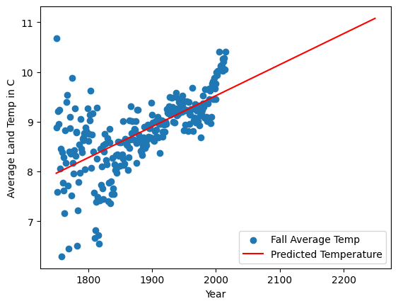

```python
from sklearn.linear_model import LinearRegression
# We reshape our x value to a 2d numpy array
x = fall_df.dt.values.reshape(-1,1)
y = fall_df.LandAverageTemperature.values
# Choose our model and train it
model = LinearRegression()
model.fit(x,y)
# Create our prediction range
new_years = np.arange(1750, 2250).reshape(-1,1)
y_pred = model.predict(new_years)
# Plot our prediction and print out the predicted values
plt.scatter(x,y,label='Fall Average Temp')
plt.plot(new_years, y_pred, 'r', label='Predicted Temperature')
plt.legend()
plt.xlabel('Year')
plt.ylabel('Average Land Temp in C')

for year, t in zip(new_years.flatten(), y_pred):
  print(f"Year {year}: Predicted Temp = {t:.2f}")
```

**Winter Average Temperarure**: The winter data set also had very similar results to the fall data set. The line had a positive slope and indicated that global warming is having a significant change on the temperature. The next graphic and code section will be a linear regression to predict how much the weather will increase in the future.

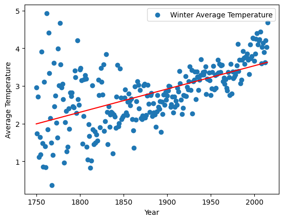

```python
x = winter_df['dt']
y = winter_df['LandAverageTemperature']
slope, intercept = np.polyfit(x,y,1)
plt.scatter(x, y, label='Winter Average Temperature')
plt.plot(x, x*slope + intercept, 'r')
plt.xlabel('Year')
plt.ylabel('Average Temperature')
plt.legend()
plt.show()
```

```
Year 1750: Predicted Temp = 1.99
Year 1751: Predicted Temp = 2.00
Year 1752: Predicted Temp = 2.00
Year 1753: Predicted Temp = 2.01
Year 1754: Predicted Temp = 2.02
Year 1755: Predicted Temp = 2.02
Year 1756: Predicted Temp = 2.03
Year 1757: Predicted Temp = 2.03
Year 1758: Predicted Temp = 2.04
Year 1759: Predicted Temp = 2.05
Year 1760: Predicted Temp = 2.05
Year 1761: Predicted Temp = 2.06
Year 1762: Predicted Temp = 2.07
Year 1763: Predicted Temp = 2.07
Year 1764: Predicted Temp = 2.08
Year 1765: Predicted Temp = 2.08
Year 1766: Predicted Temp = 2.09
Year 1767: Predicted Temp = 2.10
Year 1768: Predicted Temp = 2.10
Year 1769: Predicted Temp = 2.11
Year 1770: Predicted Temp = 2.11
Year 1771: Predicted Temp = 2.12
Year 1772: Predicted Temp = 2.13
Year 1773: Predicted Temp = 2.13
Year 1774: Predicted Temp = 2.14
Year 1775: Predicted Temp = 2.15
Year 1776: Predicted Temp = 2.15
Year 1777: Predicted Temp = 2.16
Year 1778: Predicted Temp = 2.16
Year 1779: Predicted Temp = 2.17
Year 1780: Predicted Temp = 2.18
Year 1781: Predicted Temp = 2.18
Year 1782: Predicted Temp = 2.19
Year 1783: Predicted Temp = 2.19
Year 1784: Predicted Temp = 2.20
Year 1785: Predicted Temp = 2.21
Year 1786: Predicted Temp = 2.21
Year 1787: Predicted Temp = 2.22
Year 1788: Predicted Temp = 2.23
Year 1789: Predicted Temp = 2.23
```

[output cut: 445 more lines]

```
Year 2235: Predicted Temp = 4.99
Year 2236: Predicted Temp = 4.99
Year 2237: Predicted Temp = 5.00
Year 2238: Predicted Temp = 5.01
Year 2239: Predicted Temp = 5.01
Year 2240: Predicted Temp = 5.02
Year 2241: Predicted Temp = 5.02
Year 2242: Predicted Temp = 5.03
Year 2243: Predicted Temp = 5.04
Year 2244: Predicted Temp = 5.04
Year 2245: Predicted Temp = 5.05
Year 2246: Predicted Temp = 5.06
Year 2247: Predicted Temp = 5.06
Year 2248: Predicted Temp = 5.07
Year 2249: Predicted Temp = 5.07
```

[figure not shown]

```python
# We reshape our values to fit a numpy 2d array
x = winter_df.dt.values.reshape(-1,1)
y = winter_df.LandAverageTemperature.values
# We then get our model and train it on our given data set
model = LinearRegression()
model.fit(x,y)
# Then we create our new year data to use as our prediction
new_years = np.arange(1750, 2250).reshape(-1,1)
y_pred = model.predict(new_years)
# Once we get our prediction we plot it and then print out the predicted value
plt.scatter(x,y,label='Winter Average Temp')
plt.plot(new_years, y_pred, 'r', label='Predicted Temperature')
plt.legend()
plt.xlabel('Year')
plt.ylabel('Average Land Temp in C')

for year, t in zip(new_years.flatten(), y_pred):
  print(f"Year {year}: Predicted Temp = {t:.2f}")
```

**Spring Average Temperature**:Our spring averages were pretty neutral although the line was positive the increase in the temperature was only a degree which is bad but not as bad as winter or fall.

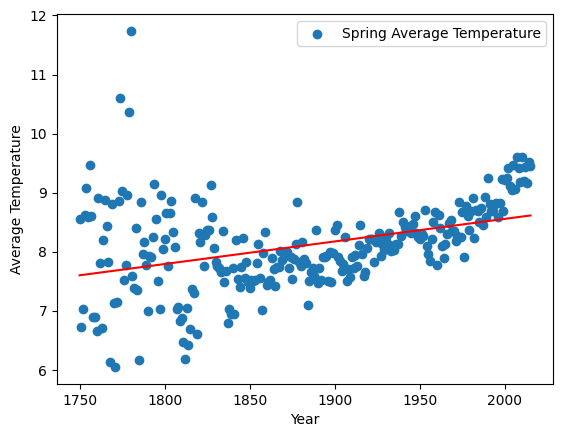

```python
x = spring_df['dt']
y = spring_df['LandAverageTemperature']
slope, intercept = np.polyfit(x,y,1)
plt.scatter(x, y, label='Spring Average Temperature')
plt.plot(x, x*slope + intercept, 'r')
plt.xlabel('Year')
plt.ylabel('Average Temperature')
plt.legend()
plt.show()
```

```
Year 1750: Predicted Temp = 7.60
Year 1751: Predicted Temp = 7.61
Year 1752: Predicted Temp = 7.61
Year 1753: Predicted Temp = 7.61
Year 1754: Predicted Temp = 7.62
Year 1755: Predicted Temp = 7.62
Year 1756: Predicted Temp = 7.63
Year 1757: Predicted Temp = 7.63
Year 1758: Predicted Temp = 7.63
Year 1759: Predicted Temp = 7.64
Year 1760: Predicted Temp = 7.64
Year 1761: Predicted Temp = 7.64
Year 1762: Predicted Temp = 7.65
Year 1763: Predicted Temp = 7.65
Year 1764: Predicted Temp = 7.66
Year 1765: Predicted Temp = 7.66
Year 1766: Predicted Temp = 7.66
Year 1767: Predicted Temp = 7.67
Year 1768: Predicted Temp = 7.67
Year 1769: Predicted Temp = 7.67
Year 1770: Predicted Temp = 7.68
Year 1771: Predicted Temp = 7.68
Year 1772: Predicted Temp = 7.69
Year 1773: Predicted Temp = 7.69
Year 1774: Predicted Temp = 7.69
Year 1775: Predicted Temp = 7.70
Year 1776: Predicted Temp = 7.70
Year 1777: Predicted Temp = 7.71
Year 1778: Predicted Temp = 7.71
Year 1779: Predicted Temp = 7.71
Year 1780: Predicted Temp = 7.72
Year 1781: Predicted Temp = 7.72
Year 1782: Predicted Temp = 7.72
Year 1783: Predicted Temp = 7.73
Year 1784: Predicted Temp = 7.73
Year 1785: Predicted Temp = 7.74
Year 1786: Predicted Temp = 7.74
Year 1787: Predicted Temp = 7.74
Year 1788: Predicted Temp = 7.75
Year 1789: Predicted Temp = 7.75
```

[output cut: 445 more lines]

```
Year 2235: Predicted Temp = 9.46
Year 2236: Predicted Temp = 9.46
Year 2237: Predicted Temp = 9.46
Year 2238: Predicted Temp = 9.47
Year 2239: Predicted Temp = 9.47
Year 2240: Predicted Temp = 9.48
Year 2241: Predicted Temp = 9.48
Year 2242: Predicted Temp = 9.48
Year 2243: Predicted Temp = 9.49
Year 2244: Predicted Temp = 9.49
Year 2245: Predicted Temp = 9.49
Year 2246: Predicted Temp = 9.50
Year 2247: Predicted Temp = 9.50
Year 2248: Predicted Temp = 9.51
Year 2249: Predicted Temp = 9.51
```

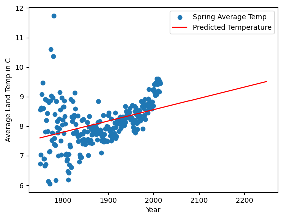

```python
# We do the same thing we did above to create our linear regression here as well
x = spring_df.dt.values.reshape(-1,1)
y = spring_df.LandAverageTemperature.values
model = LinearRegression()
model.fit(x,y)

new_years = np.arange(1750, 2250).reshape(-1,1)
y_pred = model.predict(new_years)

plt.scatter(x,y,label='Spring Average Temp')
plt.plot(new_years, y_pred, 'r', label='Predicted Temperature')
plt.legend()
plt.xlabel('Year')
plt.ylabel('Average Land Temp in C')

for year, t in zip(new_years.flatten(), y_pred):
  print(f"Year {year}: Predicted Temp = {t:.2f}")
```

**Model Evaluation**: Our model for the spring was not nearly as terrifying as the models for winter and fall. While there is an increase it won't have nearly as big of an impact as the others did.

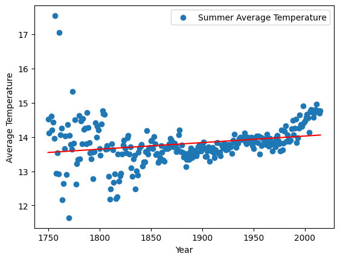

```python
summer_df = summer_df.dropna(subset=['dt','LandAverageTemperature'])
x = summer_df['dt']
y = summer_df['LandAverageTemperature']
slope, intercept = np.polyfit(x,y,1)
plt.plot(x, x*slope + intercept, 'r')
plt.scatter(x, y, label='Summer Average Temperature')
plt.xlabel('Year')
plt.ylabel('Average Temperature')
plt.legend()
plt.show()
```

```
Year 1750: Predicted Temp = 13.55
Year 1751: Predicted Temp = 13.55
Year 1752: Predicted Temp = 13.55
Year 1753: Predicted Temp = 13.55
Year 1754: Predicted Temp = 13.56
Year 1755: Predicted Temp = 13.56
Year 1756: Predicted Temp = 13.56
Year 1757: Predicted Temp = 13.56
Year 1758: Predicted Temp = 13.56
Year 1759: Predicted Temp = 13.57
Year 1760: Predicted Temp = 13.57
Year 1761: Predicted Temp = 13.57
Year 1762: Predicted Temp = 13.57
Year 1763: Predicted Temp = 13.57
Year 1764: Predicted Temp = 13.57
Year 1765: Predicted Temp = 13.58
Year 1766: Predicted Temp = 13.58
Year 1767: Predicted Temp = 13.58
Year 1768: Predicted Temp = 13.58
Year 1769: Predicted Temp = 13.58
Year 1770: Predicted Temp = 13.59
Year 1771: Predicted Temp = 13.59
Year 1772: Predicted Temp = 13.59
Year 1773: Predicted Temp = 13.59
Year 1774: Predicted Temp = 13.59
Year 1775: Predicted Temp = 13.60
Year 1776: Predicted Temp = 13.60
Year 1777: Predicted Temp = 13.60
Year 1778: Predicted Temp = 13.60
Year 1779: Predicted Temp = 13.60
Year 1780: Predicted Temp = 13.61
Year 1781: Predicted Temp = 13.61
Year 1782: Predicted Temp = 13.61
Year 1783: Predicted Temp = 13.61
Year 1784: Predicted Temp = 13.61
Year 1785: Predicted Temp = 13.62
Year 1786: Predicted Temp = 13.62
Year 1787: Predicted Temp = 13.62
Year 1788: Predicted Temp = 13.62
Year 1789: Predicted Temp = 13.62
```

[output cut: 445 more lines]

```
Year 2235: Predicted Temp = 14.48
Year 2236: Predicted Temp = 14.48
Year 2237: Predicted Temp = 14.48
Year 2238: Predicted Temp = 14.49
Year 2239: Predicted Temp = 14.49
Year 2240: Predicted Temp = 14.49
Year 2241: Predicted Temp = 14.49
Year 2242: Predicted Temp = 14.49
Year 2243: Predicted Temp = 14.50
Year 2244: Predicted Temp = 14.50
Year 2245: Predicted Temp = 14.50
Year 2246: Predicted Temp = 14.50
Year 2247: Predicted Temp = 14.50
Year 2248: Predicted Temp = 14.51
Year 2249: Predicted Temp = 14.51
```

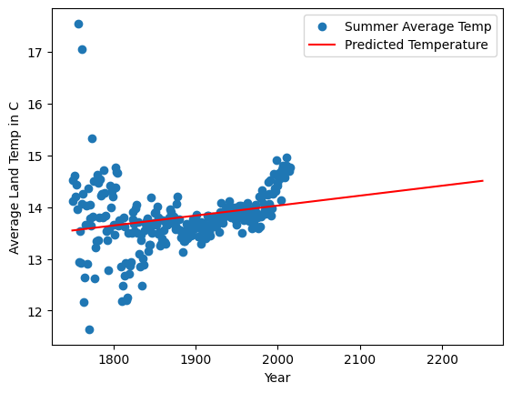

```python
# We do the same as we did previously except we had to drop our null values for the summer data frame
x = summer_df.dt.values.reshape(-1,1)
y = summer_df.LandAverageTemperature.values
model = LinearRegression()
model.fit(x,y)

new_years = np.arange(1750, 2250).reshape(-1,1)
y_pred = model.predict(new_years)

plt.scatter(x,y,label='Summer Average Temp')
plt.plot(new_years, y_pred, 'r', label='Predicted Temperature')
plt.legend()
plt.xlabel('Year')
plt.ylabel('Average Land Temp in C')

for year, t in zip(new_years.flatten(), y_pred):
  print(f"Year {year}: Predicted Temp = {t:.2f}")
```

**Model Evaluation**: For the summer the model predicted the weather would have a very minor increase, which goes to show that global warming is making its biggest presence be felt in the fall and winter. Its scary to think that the more these temperatures rise the more the ice caps melt and the higher the sea gets.